# Bankruptcy project in R

Clean workspace

```r
rm(list=ls(all=TRUE))
setwd("C:\\Users\\samanoh\\training\\besantr\\bankruptcy-project")
```

Get Data and view summary

```r
data = read.csv("Bankruptcy_data.csv", header = TRUE)
str(data)
```

```
'data.frame':   36553 obs. of  66 variables:
 $ ID    : int  1 2 3 4 5 6 7 8 9 10 ...
 $ Attr1 : num  0.13537 0.00586 0.1106 0.06391 0.13168 ...
 $ Attr2 : num  0.452 0.399 0.161 1.407 0.66 ...
 $ Attr3 : num  0.312 0.198 0.479 -0.296 0.441 ...
 $ Attr4 : num  2.047 1.939 7.571 0.529 2.71 ...
 $ Attr5 : num  10.23 9.58 263.9 -46.29 -23.6 ...
 $ Attr6 : num  0.168 0 0 -0.714 -0.2 ...
 $ Attr7 : num  0.16763 0.00724 0.13836 0.07907 0.13191 ...
 $ Attr8 : num  1.213 1.509 5.205 -0.331 0.514 ...
 $ Attr9 : num  2.255 0.979 0.684 0.985 2.136 ...
 $ Attr10: num  0.548 0.601 0.839 -0.465 0.34 ...
 $ Attr11: num  0.1833 0.0295 0.1388 0.0791 0.1861 ...
 $ Attr12: num  0.5632 0.0344 1.8983 0.1258 0.5112 ...
 $ Attr13: num  0.0892 0.0364 0.2362 0.0303 0.1671 ...
```

[output cut: 52 more lines]

COnvert target variable to categorical

```r
data$target = as.factor(as.character(data$target))
data$ID = NULL
str(data)
```

```
'data.frame':   36553 obs. of  65 variables:
 $ Attr1 : num  0.13537 0.00586 0.1106 0.06391 0.13168 ...
 $ Attr2 : num  0.452 0.399 0.161 1.407 0.66 ...
 $ Attr3 : num  0.312 0.198 0.479 -0.296 0.441 ...
 $ Attr4 : num  2.047 1.939 7.571 0.529 2.71 ...
 $ Attr5 : num  10.23 9.58 263.9 -46.29 -23.6 ...
 $ Attr6 : num  0.168 0 0 -0.714 -0.2 ...
 $ Attr7 : num  0.16763 0.00724 0.13836 0.07907 0.13191 ...
 $ Attr8 : num  1.213 1.509 5.205 -0.331 0.514 ...
 $ Attr9 : num  2.255 0.979 0.684 0.985 2.136 ...
 $ Attr10: num  0.548 0.601 0.839 -0.465 0.34 ...
 $ Attr11: num  0.1833 0.0295 0.1388 0.0791 0.1861 ...
 $ Attr12: num  0.5632 0.0344 1.8983 0.1258 0.5112 ...
 $ Attr13: num  0.0892 0.0364 0.2362 0.0303 0.1671 ...
 $ Attr14: num  0.16763 0.00724 0.13836 0.07907 0.13191 ...
```

[output cut: 51 more lines]

# Perform Random forest to find important attributes

Check for missing values

```r
sum(is.na(data))
```

```
[1] 35187
```

Perform Central imputation if missing values found

```r
library(DMwR)
```

```r
ci_data = centralImputation(data = data)
sum(is.na(ci_data))
```

```
[1] 0
```

Random forest

```r
library(caret)
library(randomForest)
```

```r
model = randomForest(target ~ ., data=ci_data, keep.forest=TRUE, do.trace=TRUE, ntrees=50)
```

```
ntree      OOB      1      2
    1:   6.27%  3.48% 58.59%
    2:   6.72%  3.75% 63.28%
    3:   6.65%  3.62% 65.52%
    4:   6.49%  3.36% 67.31%
    5:   6.19%  3.07% 67.31%
    6:   5.96%  2.84% 67.15%
    7:   5.71%  2.54% 68.04%
    8:   5.45%  2.27% 67.98%
    9:   5.23%  2.00% 68.74%
   10:   5.08%  1.79% 69.91%
   11:   4.90%  1.61% 69.82%
   12:   4.74%  1.46% 69.34%
   13:   4.59%  1.25% 70.26%
   14:   4.47%  1.12% 70.49%
```

[output cut: 486 more lines]

Find importance from the model

```r
model$importance
```

```
       MeanDecreaseGini
Attr1          35.29620
Attr2          32.93313
Attr3          41.70072
Attr4          41.88159
Attr5          60.70844
Attr6          62.86490
Attr7          36.17985
Attr8          35.09011
Attr9          74.29533
Attr10         34.63240
Attr11         41.61080
Attr12         36.61932
Attr13         48.29026
Attr14         36.12115
Attr15         48.08141
Attr16         47.76401
Attr17         33.06997
Attr18         35.50314
Attr19         37.35886
Attr20         45.82591
Attr21         40.63864
Attr22         54.39903
Attr23         36.77528
Attr24         89.96429
Attr25         48.83975
Attr26         50.00922
Attr27        222.66239
Attr28         37.72288
Attr29         68.53025
Attr30         40.80580
Attr31         40.74540
Attr32         36.87775
Attr33         41.32616
Attr34        143.84128
Attr35         68.58714
Attr36         52.01134
Attr37         33.88303
Attr38         43.39254
Attr39         66.85303
```

[output cut: 10 more lines]

```
Attr50         38.76878
Attr51         37.31198
Attr52         37.77025
Attr53         34.65658
Attr54         40.74438
Attr55         56.53644
Attr56         89.99113
Attr57         39.07007
Attr58        105.37562
Attr59         26.51705
Attr60         47.09811
Attr61         57.42337
Attr62         33.74721
Attr63         36.26030
Attr64         36.92218
```

Extract important attributes in data frame

```r
rf_imp_attr = data.frame(model$importance)
rf_imp_attr = data.frame(row.names(rf_imp_attr), rf_imp_attr[,1])
colnames(rf_imp_attr) = c("Attributes", "Importance")
rf_imp_attr = rf_imp_attr[order(rf_imp_attr$Importance, decreasing = TRUE),]
rf_imp_attr
```

|  | Attributes | Importance |
| --- | --- | --- |
| 27 | Attr27 | 222.66239 |
| 34 | Attr34 | 143.84128 |
| 46 | Attr46 | 116.91267 |
| 58 | Attr58 | 105.37562 |
| 56 | Attr56 | 89.99113 |
| 24 | Attr24 | 89.96429 |
| 9 | Attr9 | 74.29533 |
| 35 | Attr35 | 68.58714 |
| 29 | Attr29 | 68.53025 |
| 39 | Attr39 | 66.85303 |

[output cut: 54 more lines]

Plot important attributes in graph

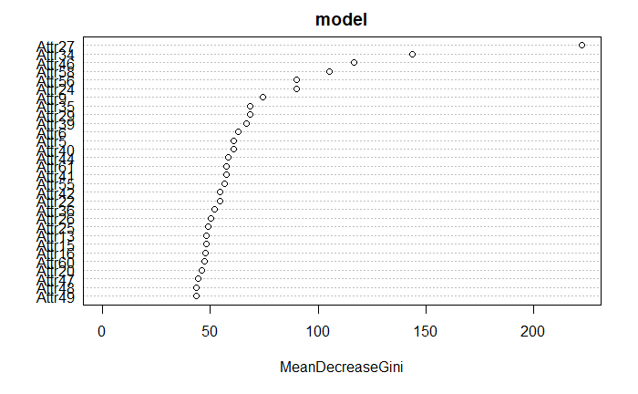

```r
varImpPlot(model)
```

# Select top 6 based on the importance

```r
imp_attr = as.character(rf_imp_attr$Attributes[1:6])
imp_attr
```

```
[1] "Attr27" "Attr34" "Attr46" "Attr58" "Attr56" "Attr24"
```

Select important attributes from actual data and perform iterations

```r
imp_data = data[imp_attr]
imp_data_full <- imp_data
imp_data_full$target <- data$target
str(imp_data_full)
```

```
'data.frame':   36553 obs. of  7 variables:
 $ Attr27: num  11.554 0.271 249.3 0.435 3.371 ...
 $ Attr34: num  4.598 1.95 3.568 0.098 2.878 ...
 $ Attr46: num  1.213 1.192 6.577 0.359 0.889 ...
 $ Attr58: num  0.926 0.793 0.807 1.015 0.939 ...
 $ Attr56: num  0.0787 0.2697 0.1599 -0.0153 0.1102 ...
 $ Attr24: num  0.1676 0.0578 0.2354 -0.6893 0.2086 ...
 $ target: Factor w/ 2 levels "0","1": 1 1 1 1 1 1 1 1 1 1 ...
```

# Perform outlier analysis - Box plot

First Feature - original Attr27

```
          [,1]
[1,] -7.663000
[2,]  0.042639
[3,]  1.090050
[4,]  5.180500
[5,] 12.887000
```

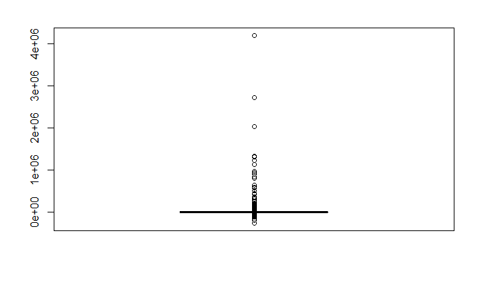

```r
boxplot(imp_data_full$Attr27)$stats
```

First feature - outlied Attr27

```
         [,1]
[1,] -7.53510
[2,]  0.04179
[3,]  1.08300
[4,]  5.10670
[5,] 12.70400
```

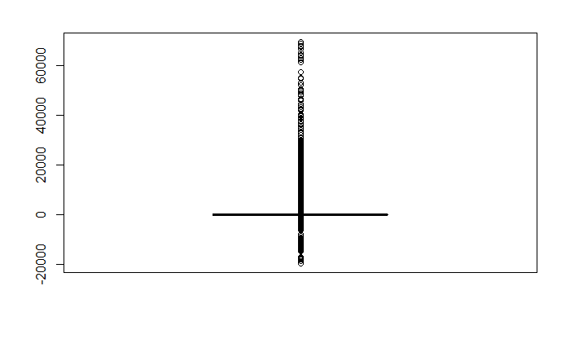

```r
imp_data_full$Attr27 = ifelse(imp_data_full$Attr27 >= 70000, NA, imp_data_full$Attr27)
imp_data_full$Attr27 = ifelse(imp_data_full$Attr27 <= -20000, NA, imp_data_full$Attr27)
boxplot(imp_data_full$Attr27)$stats
```

Second Feature - original Attr34

```
        [,1]
[1,] -6.0282
[2,]  0.3115
[3,]  1.9779
[4,]  4.5613
[5,] 10.9360
```

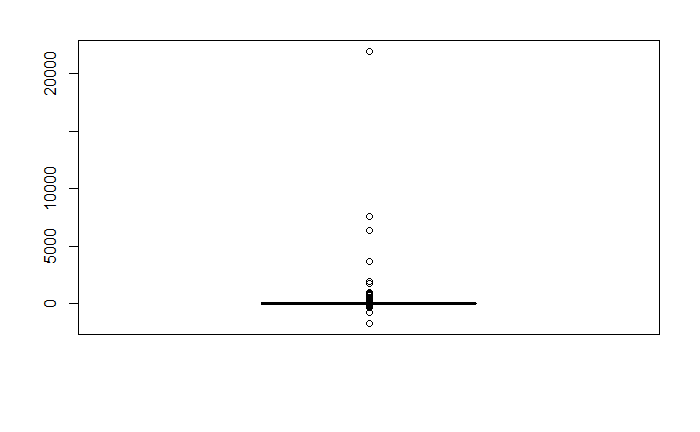

```r
boxplot(imp_data_full$Attr34)$stats
```

Second feature - outlied Attr34

```
         [,1]
[1,] -6.02820
[2,]  0.31107
[3,]  1.97335
[4,]  4.54350
[5,] 10.89000
```

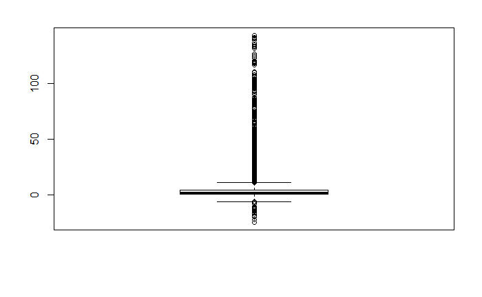

```r
imp_data_full$Attr34 = ifelse(imp_data_full$Attr34 >= 150, NA, imp_data_full$Attr34)
imp_data_full$Attr34 = ifelse(imp_data_full$Attr34 <= -25, NA, imp_data_full$Attr34)
boxplot(imp_data_full$Attr34)$stats
```

Third attribute - original Attr46

```
         [,1]
[1,] -0.17735
[2,]  0.60823
[3,]  1.02800
[4,]  1.91540
[5,]  3.87600
```

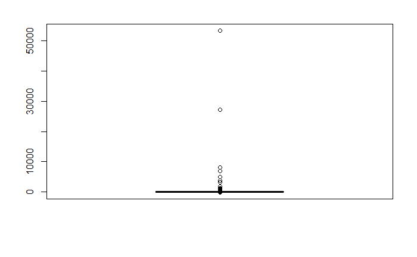

```r
boxplot(imp_data_full$Attr46)$stats
```

Third attribute - outlied Attr46

```
         [,1]
[1,] -0.17735
[2,]  0.60711
[3,]  1.02580
[4,]  1.90500
[5,]  3.85100
```

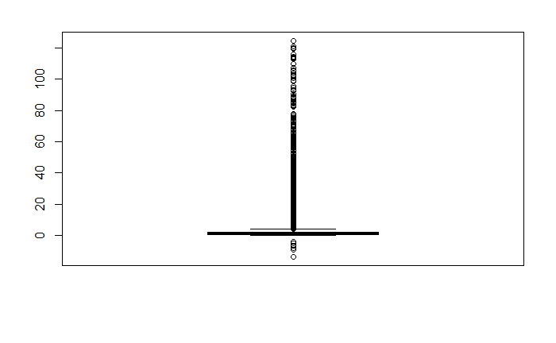

```r
imp_data_full$Attr46 = ifelse(imp_data_full$Attr46 >= 125, NA, imp_data_full$Attr46)
imp_data_full$Attr46 = ifelse(imp_data_full$Attr46 <= -50, NA, imp_data_full$Attr46)
boxplot(imp_data_full$Attr46)$stats
```

Fourth attribute - original Attr58

```
        [,1]
[1,] 0.69901
[2,] 0.87519
[3,] 0.95086
[4,] 0.99271
[5,] 1.16890
```

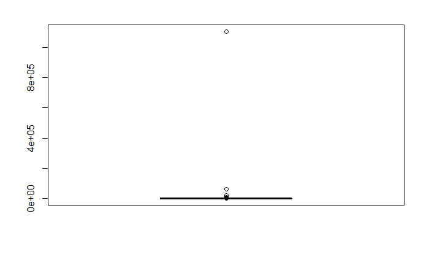

```r
boxplot(imp_data_full$Attr58)$stats
```

Fourth attribte - Outlied Attr58

```
         [,1]
[1,] 0.699680
[2,] 0.875350
[3,] 0.950765
[4,] 0.992480
[5,] 1.168100
```

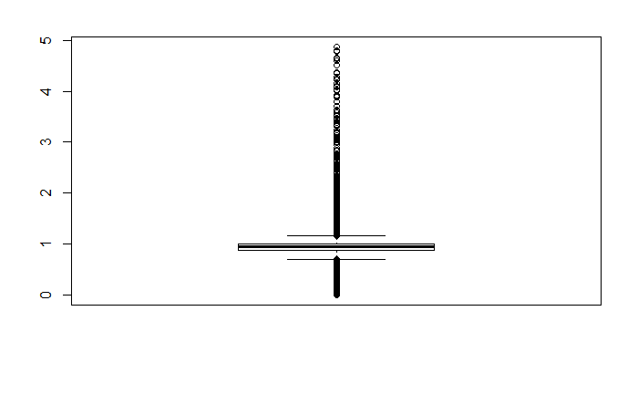

```r
imp_data_full$Attr58 = ifelse(imp_data_full$Attr58 >= 5, NA, imp_data_full$Attr58)
imp_data_full$Attr58 = ifelse(imp_data_full$Attr58 <= 0, NA, imp_data_full$Attr58)
boxplot(imp_data_full$Attr58)$stats
```

Fifth Attribute - original Attr56

```
           [,1]
[1,] -0.1713100
[2,]  0.0091442
[3,]  0.0529365
[4,]  0.1294550
[5,]  0.3098900
```

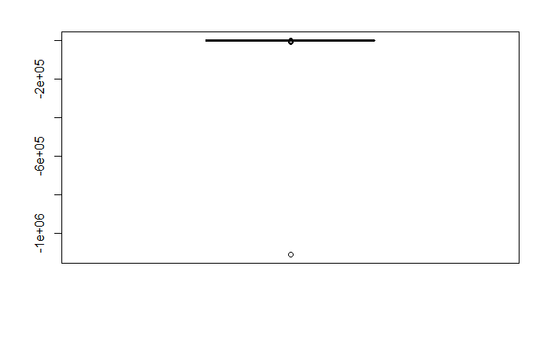

```r
boxplot(imp_data_full$Attr56)$stats
```

Fifth Attribute - outlied Attr56

```
           [,1]
[1,] -0.1661400
[2,]  0.0090615
[3,]  0.0523790
[4,]  0.1266900
[5,]  0.3031300
```

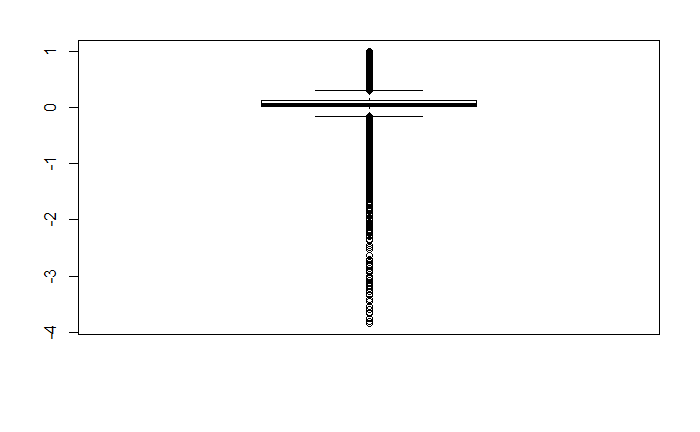

```r
imp_data_full$Attr56 = ifelse(imp_data_full$Attr56 >= 1, NA, imp_data_full$Attr56)
imp_data_full$Attr56 = ifelse(imp_data_full$Attr56 <= -4, NA, imp_data_full$Attr56)
boxplot(imp_data_full$Attr56)$stats
```

Sixth Attribute - original Attr24

```
           [,1]
[1,] -0.4796700
[2,]  0.0212365
[3,]  0.1549600
[4,]  0.3558700
[5,]  0.8577600
```

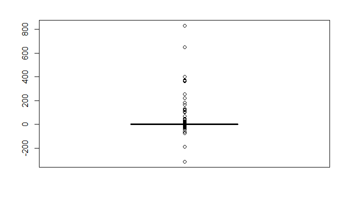

```r
boxplot(imp_data_full$Attr24)$stats
```

Sixth attribute - outlied Attr24

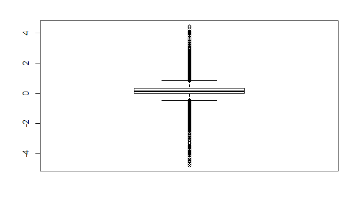

```r
imp_data_full$Attr24 = ifelse(imp_data_full$Attr24 >= 4.5, NA, imp_data_full$Attr24)
imp_data_full$Attr24 = ifelse(imp_data_full$Attr24 <= -5, NA, imp_data_full$Attr24)
boxplot(imp_data_full$Attr24)
```

# Missing value treatment - KNN imputation

Check missing values

```r
sum(is.na(imp_data_full))
```

```
[1] 4437
```

Import libraries

```r
library(DMwR)
```

```r
#str(imp_data)
#rowsum(is.na(imp_data))
imp_data_no_na = imp_data_full[rowSums(is.na(imp_data_full)) <= 3,]
str(imp_data_no_na)
```

```
'data.frame':   36518 obs. of  7 variables:
 $ Attr27: num  11.554 0.271 249.3 0.435 3.371 ...
 $ Attr34: num  4.598 1.95 3.568 0.098 2.878 ...
 $ Attr46: num  1.213 1.192 6.577 0.359 0.889 ...
 $ Attr58: num  0.926 0.793 0.807 1.015 0.939 ...
 $ Attr56: num  0.0787 0.2697 0.1599 -0.0153 0.1102 ...
 $ Attr24: num  0.1676 0.0578 0.2354 -0.6893 0.2086 ...
 $ target: Factor w/ 2 levels "0","1": 1 1 1 1 1 1 1 1 1 1 ...
```

```r
imp_data_knn_imputed = knnImputation(imp_data_no_na, k = 7, scale = T, meth = "weighAvg", distData = NULL)
sum(is.na(imp_data_knn_imputed))
```

```
[1] 0
```

Export to CSV

```r
write.csv(imp_data_knn_imputed, file="bankruptcy_imp_knn_imputed.csv")
```

# Train test split

Split imputed data

```r
set.seed(88)
trainrows = createDataPartition(y=imp_data_knn_imputed$target, p=0.8, list = FALSE)
train_split = imp_data_knn_imputed[trainrows,]
val_split = imp_data_knn_imputed[-trainrows,]
```

# Build Model - Logistic regression

Build model with glm for logistic regression

```r
log_reg_model = glm(formula = target~., data = train_split, family = binomial)
```

Predict the model from val_data

```r
log_reg_prediction = predict(log_reg_model, newdata=val_split[-7], type="response")
```

View predicted output

```r
View(round(log_reg_prediction,3))
```

# Logistic regression Model - apply cutoff based on distribution

Identify cutoff

```r
summary(imp_data_knn_imputed$target)
```

```
    0     1
34755  1763
```

```r
cutoff = 1763/34755
cutoff
```

```
[1] 0.05072651
```

Apply cutoff on prediction

```r
log_reg_output = ifelse(log_reg_prediction >= cutoff, 1, 0)
log_reg_output = as.factor(as.character(log_reg_output))
summary(log_reg_output)
```

```
   0    1
5120 2183
```

# Metrics - Logistic regression without ROC

Import library

```r
library("MLmetrics")
```

Plot Confusion matrix

```r
confusionMatrix(log_reg_output, val_split$target)
```

```
Confusion Matrix and Statistics

          Reference
Prediction    0    1
         0 4978  142
         1 1973  210

               Accuracy : 0.7104
                 95% CI : (0.6998, 0.7208)
    No Information Rate : 0.9518
    P-Value [Acc > NIR] : 1

                  Kappa : 0.0902
 Mcnemar's Test P-Value : <2e-16

            Sensitivity : 0.7162
            Specificity : 0.5966
         Pos Pred Value : 0.9723
         Neg Pred Value : 0.0962
             Prevalence : 0.9518
         Detection Rate : 0.6816
   Detection Prevalence : 0.7011
      Balanced Accuracy : 0.6564

       'Positive' Class : 0
```

Calculate categorical metrics - Recall

```r
Recall(log_reg_output, val_split$target)
```

```
[1] 0.9722656
```

Calculate categorical metrics - precision

```r
Precision(log_reg_output, val_split$target)
```

```
[1] 0.7161559
```

Calculate categorical metrics - F1 score

```r
F1_Score(log_reg_output, val_split$target)
```

```
[1] 0.8247867
```